# Predictive Machine Learning: Project

2015-02-22

## Executive Summary

Predictive Machine Learning is employed in this document to guess the type of exercise based on the data collected by accelerometers on the belt, forearm, arm, and dumbell of 6 participants of the experiment. The Random Forest algorithm is applied to a training data set, resulting in a model of high predictive accuracy and low out-of-sample error.

## 1. Data Set

The data set used in the analysis comes from [the website](http://groupware.les.inf.puc-rio.br/har).

Packages and options needed for the analysis.

```r
library(caret)
library(dplyr)
library(tidyr)
library(magrittr)
library(randomForest)
library(pander)
library(knitr)

opts_chunk$set(fig.width = 10, fig.height = 7, warning = FALSE, message = FALSE, cache = TRUE)
panderOptions("table.split.table", Inf)
```

The data is loaded into the environment.

```r
training.csv <- read.csv("data/pml-training.csv")
testing.csv <- read.csv("data/pml-testing.csv")
```

## 2. Exploratory Data Analysis

Summary of the data: in the training set there are 19622 observations of 160 variables. The number of cases in each of the classes is presented below.

```r
training.csv %$% table(classe) %>% pander
```

| A | B | C | D | E |
| --- | --- | --- | --- | --- |
| 5580 | 3797 | 3422 | 3216 | 3607 |

The data set consists of three groups of variables.

- columns 1 to 7 represent the identification data of the cases (excluded from the analysis),
- one hundred variables consists mainly of NA’s and empty strings (excluded from the analysis),
- the remaining 53 variables (52 predictors and 1 response) are the input for the model.

As shown below, the second and third group are very distinct when it comes to valid data points.

```r
training.long <- training.csv %>% tbl_df %>% gather %>% group_by(key) %>%
    summarise(valid = 1 - sum(is.na(value) | value == "") / n())

training.long %$% table(valid) %>% pander
```

| 0.020691061053919 | 1 |
| --- | --- |
| 100 | 60 |

We can see that only 60 variables have full coverage, out of which the first seven (ID variables) are not used in the model.

```r
variables <- training.long %>% filter(valid == 1) %$% key %>% .[8:60]
```

## 3. Model Preparation

The data partition is performed. In the training data set, we put aside a validation data set of the size of 30%. This validation data set will be used to assess the out-of-sample accuracy of the model.

```r
set <- createDataPartition(training.csv$classe, p = 0.7, list = FALSE)

training.set <- training.csv[set, variables]
validation.set <- training.csv[-set, variables]
testing.set <- testing.csv[, variables[-53]]
```

## 4. Model Fitting

In the next step, the model is fit, giving 100% accuracy in the training data set, and 99.4% accuracy in the validation data set.

```r
fit <- randomForest(classe ~ ., training.set)
confusionMatrix(predict(fit, training.set), training.set$classe)
```

```
## Confusion Matrix and Statistics
##
##           Reference
## Prediction    A    B    C    D    E
##          A 3906    0    0    0    0
##          B    0 2658    0    0    0
##          C    0    0 2396    0    0
##          D    0    0    0 2252    0
##          E    0    0    0    0 2525
##
## Overall Statistics
##
##                Accuracy : 1
##                  95% CI : (0.9997, 1)
##     No Information Rate : 0.2843
##     P-Value [Acc > NIR] : < 2.2e-16
##
##                   Kappa : 1
##  Mcnemar's Test P-Value : NA
##
## Statistics by Class:
##
##                      Class: A Class: B Class: C Class: D Class: E
## Sensitivity            1.0000   1.0000   1.0000   1.0000   1.0000
## Specificity            1.0000   1.0000   1.0000   1.0000   1.0000
## Pos Pred Value         1.0000   1.0000   1.0000   1.0000   1.0000
## Neg Pred Value         1.0000   1.0000   1.0000   1.0000   1.0000
## Prevalence             0.2843   0.1935   0.1744   0.1639   0.1838
## Detection Rate         0.2843   0.1935   0.1744   0.1639   0.1838
## Detection Prevalence   0.2843   0.1935   0.1744   0.1639   0.1838
## Balanced Accuracy      1.0000   1.0000   1.0000   1.0000   1.0000
```

```r
confusionMatrix(predict(fit, validation.set), validation.set$classe)
```

```
## Confusion Matrix and Statistics
##
##           Reference
## Prediction    A    B    C    D    E
##          A 1673    9    0    0    0
##          B    1 1130    4    0    0
##          C    0    0 1020   15    0
##          D    0    0    2  946    3
##          E    0    0    0    3 1079
##
## Overall Statistics
##
##                Accuracy : 0.9937
##                  95% CI : (0.9913, 0.9956)
##     No Information Rate : 0.2845
##     P-Value [Acc > NIR] : < 2.2e-16
##
##                   Kappa : 0.992
##  Mcnemar's Test P-Value : NA
##
## Statistics by Class:
##
##                      Class: A Class: B Class: C Class: D Class: E
## Sensitivity            0.9994   0.9921   0.9942   0.9813   0.9972
## Specificity            0.9979   0.9989   0.9969   0.9990   0.9994
## Pos Pred Value         0.9946   0.9956   0.9855   0.9947   0.9972
## Neg Pred Value         0.9998   0.9981   0.9988   0.9964   0.9994
## Prevalence             0.2845   0.1935   0.1743   0.1638   0.1839
## Detection Rate         0.2843   0.1920   0.1733   0.1607   0.1833
## Detection Prevalence   0.2858   0.1929   0.1759   0.1616   0.1839
## Balanced Accuracy      0.9986   0.9955   0.9955   0.9902   0.9983
```

```r
varImp(fit) %>% add_rownames %>% arrange(-Overall) %>% head(10) %>% pander
```

| rowname | Overall |
| --- | --- |
| roll_belt | 869.2 |
| yaw_belt | 618.1 |
| pitch_forearm | 553.9 |
| magnet_dumbbell_z | 522.1 |
| pitch_belt | 480.1 |
| magnet_dumbbell_y | 479.3 |
| roll_forearm | 427.8 |
| magnet_dumbbell_x | 333.3 |
| roll_dumbbell | 293.7 |
| accel_dumbbell_y | 284.9 |

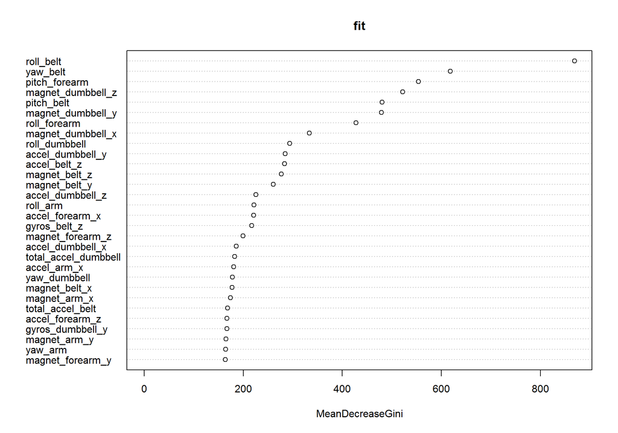

```r
varImpPlot(fit)
```

## 5. Model Tuning

In the last step, only 7 of the most important variables are taken as predictors in the final model. Significant reduction in the number of predictors (7 rather than 52) allows us to keep the out-of-sample error small. The overall model accuracy goes down from 99.4% to 98.5%, the error still being small (1.5%).

```r
variables.kiss <- varImp(fit) %>% add_rownames %>% top_n(7, Overall) %$% rowname %>% c("classe")

fit.kiss <- randomForest(classe ~ ., training.set[, variables.kiss])
confusionMatrix(predict(fit.kiss, training.set), training.set$classe)
```

```
## Confusion Matrix and Statistics
##
##           Reference
## Prediction    A    B    C    D    E
##          A 3895    2    0    0    0
##          B    1 2656    4    0    0
##          C    8    0 2391    0    0
##          D    2    0    1 2252    0
##          E    0    0    0    0 2525
##
## Overall Statistics
##
##                Accuracy : 0.9987
##                  95% CI : (0.9979, 0.9992)
##     No Information Rate : 0.2843
##     P-Value [Acc > NIR] : < 2.2e-16
##
##                   Kappa : 0.9983
##  Mcnemar's Test P-Value : NA
##
## Statistics by Class:
##
##                      Class: A Class: B Class: C Class: D Class: E
## Sensitivity            0.9972   0.9992   0.9979   1.0000   1.0000
## Specificity            0.9998   0.9995   0.9993   0.9997   1.0000
## Pos Pred Value         0.9995   0.9981   0.9967   0.9987   1.0000
## Neg Pred Value         0.9989   0.9998   0.9996   1.0000   1.0000
## Prevalence             0.2843   0.1935   0.1744   0.1639   0.1838
## Detection Rate         0.2835   0.1933   0.1741   0.1639   0.1838
## Detection Prevalence   0.2837   0.1937   0.1746   0.1642   0.1838
## Balanced Accuracy      0.9985   0.9994   0.9986   0.9999   1.0000
```

```r
confusionMatrix(predict(fit.kiss, validation.set), validation.set$classe)
```

```
## Confusion Matrix and Statistics
##
##           Reference
## Prediction    A    B    C    D    E
##          A 1653   14    0    0    0
##          B    9 1101    4    6    8
##          C   11   13 1013    2    1
##          D    1    7    9  956    0
##          E    0    4    0    0 1073
##
## Overall Statistics
##
##                Accuracy : 0.9849
##                  95% CI : (0.9814, 0.9878)
##     No Information Rate : 0.2845
##     P-Value [Acc > NIR] : < 2.2e-16
##
##                   Kappa : 0.9809
##  Mcnemar's Test P-Value : NA
##
## Statistics by Class:
##
##                      Class: A Class: B Class: C Class: D Class: E
## Sensitivity            0.9875   0.9666   0.9873   0.9917   0.9917
## Specificity            0.9967   0.9943   0.9944   0.9965   0.9992
## Pos Pred Value         0.9916   0.9761   0.9740   0.9825   0.9963
## Neg Pred Value         0.9950   0.9920   0.9973   0.9984   0.9981
## Prevalence             0.2845   0.1935   0.1743   0.1638   0.1839
## Detection Rate         0.2809   0.1871   0.1721   0.1624   0.1823
## Detection Prevalence   0.2833   0.1917   0.1767   0.1653   0.1830
## Balanced Accuracy      0.9921   0.9805   0.9909   0.9941   0.9954
```

## 6. Results

```r
testing.pred <- predict(fit.kiss, testing.set)
testing.pred %>% pander
```

| 1 | 2 | 3 | 4 | 5 | 6 | 7 | 8 | 9 | 10 | 11 | 12 | 13 | 14 | 15 | 16 | 17 | 18 | 19 | 20 |
| --- | --- | --- | --- | --- | --- | --- | --- | --- | --- | --- | --- | --- | --- | --- | --- | --- | --- | --- | --- |
| B | A | B | A | A | E | D | B | A | A | B | C | B | A | E | E | A | B | B | B |

```r
testing.pred.kiss <- predict(fit.kiss, testing.set)
testing.pred.kiss %>% pander
```

| 1 | 2 | 3 | 4 | 5 | 6 | 7 | 8 | 9 | 10 | 11 | 12 | 13 | 14 | 15 | 16 | 17 | 18 | 19 | 20 |
| --- | --- | --- | --- | --- | --- | --- | --- | --- | --- | --- | --- | --- | --- | --- | --- | --- | --- | --- | --- |
| B | A | B | A | A | E | D | B | A | A | B | C | B | A | E | E | A | B | B | B |

```r
identical(testing.pred, testing.pred.kiss)
```

```
## [1] TRUE
```

The vector of predicted classes are written down to files and then used in the assignment.

```r
pml_write_files <- function(x) {
    n = length(x)
    for (i in 1:n) {
        filename = paste0("data/problem_id_", i, ".txt")
        write.table(x[i], file = filename, quote = FALSE, row.names = FALSE, col.names = FALSE)
    }
}

pml_write_files(testing.pred.kiss)
```